# Credit Score Classification – EDA & Project Plan

# Overview of the problem

The goal of this project is to build a multi-class classification model to predict a customer’s Credit Score (Poor, Standard, Good) using demographic and financial behavior data. This can support automated risk assessment in financial institutions and reduce manual workload.

## Why this problem is interesting

- Real-world impact: Credit score classification plays a crucial role in lending decisions, insurance pricing, and financial eligibility assessments.
- Data complexity: The dataset presents real-life challenges including:
- Missing values
- Noisy and inconsistent entries (e.g. placeholders like “_______”, symbols like #F%$D)
- Class imbalance
- Outliers and corrupted numeric fields
- Machine learning relevance: Offers a rich opportunity to apply supervised classification techniques, handle imbalanced classes, and test advanced models like Random Forest and XGBoost.

# Dataset Overview

- Source: Kaggle (https://www.kaggle.com/code/sudhanshu2198/multi-class-credit-score-classification)
- train.csv: Used for EDA, data cleaning, and model training. Contains features and the target label Credit_Score.
- test.csv: Used to evaluate model performance on unseen data. Contains features only.
- score.csv: Used for final predictions and submission. Same structure as the test set.
- Samples ~100,000
- Features: Mix of numeric and categorical
- Target: Credit_Score (Poor, Standard, Good)
- Key Issues: Outliers, noisy strings, class imbalance
- Missing Values ~1% overall; highest in Credit_History_Age, Monthly_Inhand_Salary

# Missing Value Assessment

```r
colSums(is.na(train))
```

```
                      ID              Customer_ID                    Month
                       0                        0                        0
                    Name                      Age                      SSN
                       0                        0                        0
              Occupation            Annual_Income    Monthly_Inhand_Salary
                       0                        0                    15002
       Num_Bank_Accounts          Num_Credit_Card            Interest_Rate
                       0                        0                        0
             Num_of_Loan             Type_of_Loan      Delay_from_due_date
                       0                        0                        0
  Num_of_Delayed_Payment     Changed_Credit_Limit     Num_Credit_Inquiries
                       0                        0                     1965
              Credit_Mix         Outstanding_Debt Credit_Utilization_Ratio
                       0                        0                        0
      Credit_History_Age    Payment_of_Min_Amount      Total_EMI_per_month
                    9030                        0                        0
 Amount_invested_monthly        Payment_Behaviour          Monthly_Balance
                       0                        0                        0
            Credit_Score
                       0
```

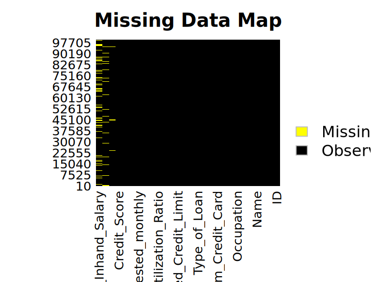

```r
missmap(train, main = "Missing Data Map", col = c("yellow", "black"))
```

# Data Cleaning and Type Fixes

```r
clean_numeric <- function(x) {
  x <- gsub(",", "", as.character(x))
  x <- gsub("[$%]", "", x)
  x <- gsub("[^0-9\\\\.\\\\-]", "", x)
  suppressWarnings(as.numeric(x))
}

cols_to_clean <- c("Age", "Annual_Income", "Outstanding_Debt", "Num_of_Loan",
                   "Changed_Credit_Limit", "Num_of_Delayed_Payment",
                   "Amount_invested_monthly", "Monthly_Balance")

for (col in intersect(cols_to_clean, names(train))) {
  train[[col]] <- clean_numeric(train[[col]])
}

train$Credit_Mix <- as.factor(train$Credit_Mix)
train$Payment_of_Min_Amount <- as.factor(train$Payment_of_Min_Amount)
```

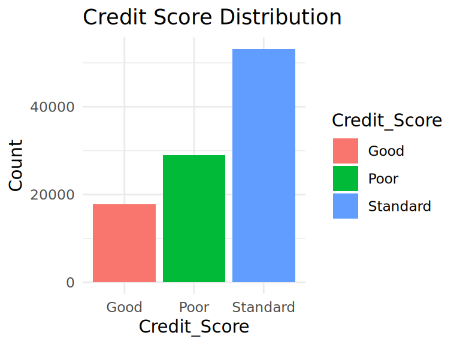

```r
ggplot(train, aes(x = Credit_Score, fill = Credit_Score)) +
  geom_bar() +
  labs(title = "Credit Score Distribution", y = "Count") +
  theme_minimal()
```

The dataset has class imbalance, with the “Standard” credit score category being the most prevalent, followed by “Poor” and then “Good”, which may bias classification models and necessitates the use of resampling or class-weighting techniques.

# Outlier Detection

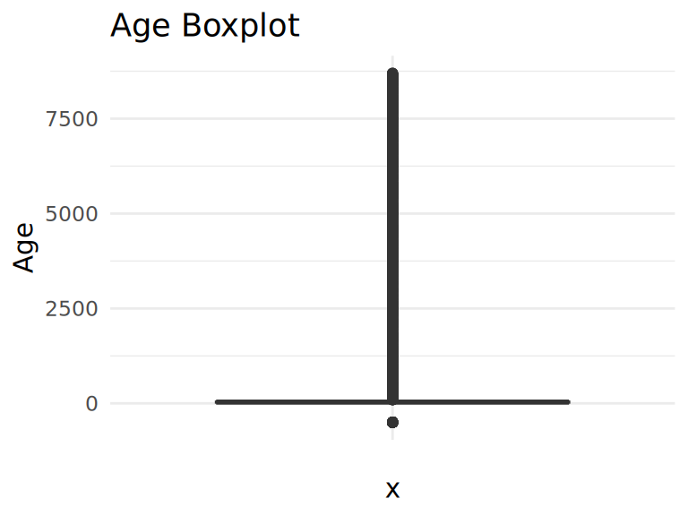

```r
ggplot(train, aes(x = "", y = Age)) +
  geom_boxplot(fill = "orange") +
  labs(title = "Age Boxplot") +
  theme_minimal()
```

The boxplot of the Age variable reveals the presence of extreme outliers, with some values exceeding 7500, which are clearly unrealistic and indicate data entry errors. These anomalies should be investigated and removed or corrected to ensure accurate analysis and model training.

# Correlation and PCA

## Correlation Matrix (Simplified for Clarity)

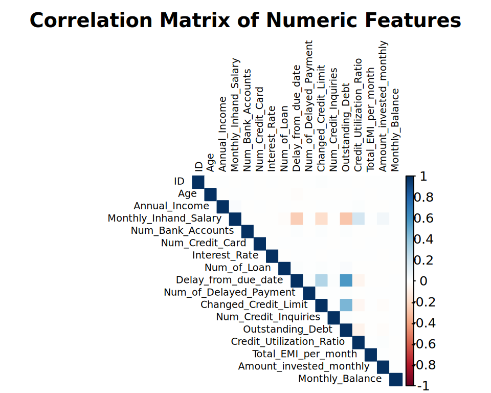

```r
library(corrplot)

# Select only numeric columns and drop NAs
numeric_data <- train %>%
  select(where(is.numeric)) %>%
  drop_na()

# Simple and clean correlation heatmap
corrplot(
  cor(numeric_data),
  method = "color",
  type = "upper",           # Upper triangle only
  tl.cex = 0.6,             # Label font size
  tl.col = "black",         # Label color
  mar = c(0, 0, 2, 0),      # Margin to fit the title
  title = "Correlation Matrix of Numeric Features"
)
```

## PCA Plot

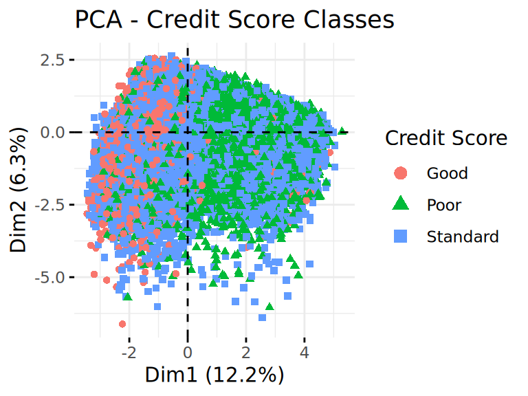

```r
pca_data <- train %>%
  select(where(is.numeric)) %>%
  na.omit()

credit_labels <- train$Credit_Score[as.numeric(rownames(pca_data))]

pca_scaled <- scale(pca_data)
pca_result <- prcomp(pca_scaled, center = TRUE, scale. = TRUE)

fviz_pca_ind(pca_result,
             geom.ind = "point",
             col.ind = as.factor(credit_labels),
             legend.title = "Credit Score") +
  labs(title = "PCA - Credit Score Classes")
```

# Evaluation Metrics & Algorithms

The classification model will be evaluated using several key metrics suited for multi-class problems:  
- Accuracy: Measures the overall correctness of predictions.  
- Precision, Recall, and F1-Score (calculated per class): Help assess how well the model distinguishes between Poor, Standard, and Good credit scores.  
- Macro and Weighted F1-Scores: Macro F1 treats all classes equally, while Weighted F1 adjusts for class imbalance by accounting for the frequency of each class.  
Confusion Matrix: Offers a detailed breakdown of correct and incorrect classifications to identify potential model bias or confusion between classes.  
Model performance will be validated using k-fold cross-validation to ensure generalizability. Metrics will be computed on both training and test sets, with emphasis on F1 performance.  
The following algorithms will be implemented and compared:  
- Logistic Regression: A baseline linear model for multi-class classification.  
- Decision Tree: A simple and interpretable non-linear model.  
- Random Forest: An ensemble approach that reduces overfitting through averaging.  
- XGBoost: A gradient boosting framework optimized for speed and performance, particularly in structured data tasks.

# Project Plan

## Phase Plan (3 Phases)

- **Phase 1**: Data Cleaning & Exploration
- **Phase 2**: Modeling & Evaluation (Logistic, Tree, RF, XGBoost)
- **Phase 3**: Prediction & Reporting

## Data Usage

- **`train.csv`** will be used for data cleaning, EDA, model training, and validation. It contains both features and the target label (`Credit_Score`).
- **`test.csv`** will be used to evaluate the trained model on unseen data. It contains input features but no labels.
- **`score.csv`** will be used for final prediction and model deployment simulation. It is structurally similar to the test set and is used to demonstrate how the model performs in real-world application.

## Weekly Timeline with Subtasks

[output not shown]

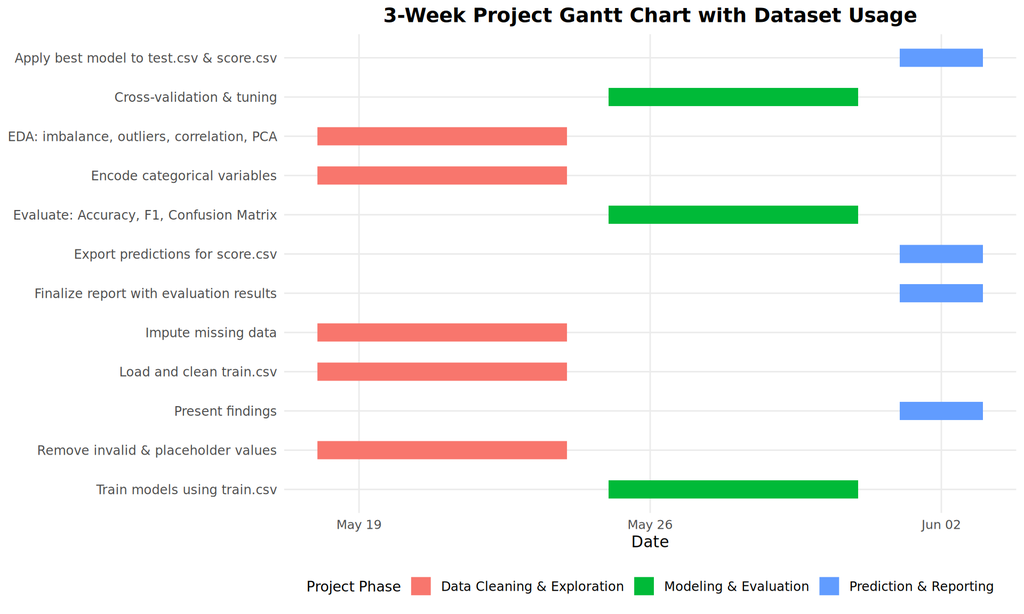